# 기말시험

2018.6.19

# 1 문제 0

씨앗값으로 다음의 청크 안에 자기 학번을 집어 넣으시오.  
mlbench 패키지를 설치하고 library 명령어로 불러오시오.  
기타 필요한 패키지는 알아서 설치하고, 청크 안에 library 명령어로 불러오시오.

```r
nn = 201241021 # 12345 대신 자기 학번
set.seed(nn)
library(mlbench)
```

Pima Indians Diabetes Database

pregnant Number of times pregnant  
glucose Plasma glucose concentration (glucose tolerance test)  
pressure Diastolic blood pressure (mm Hg)  
triceps Triceps skin fold thickness (mm)  
insulin 2-Hour serum insulin (mu U/ml)  
mass Body mass index (weight in kg/(height in m)^2)  
pedigree Diabetes pedigree function  
age Age (years)  
diabetes Class variable (test for diabetes)

다음의 코드를 실행해서 dt1 데이터 프레임(data.frame)을 만드시오. 이하 dt1을 가지고 문제를 푸시오.

```r
data(PimaIndiansDiabetes)

dt1 = PimaIndiansDiabetes
dt1 = dt1[-(nn %% 400), ]
```

자료를 이리저리 살펴 보시오.

```r
dim(dt1)
```

```
## [1] 767   9
```

```r
names(dt1)
```

```
## [1] "pregnant" "glucose"  "pressure" "triceps"  "insulin"  "mass"
## [7] "pedigree" "age"      "diabetes"
```

```r
head(dt1)
```

```
##   pregnant glucose pressure triceps insulin mass pedigree age diabetes
## 1        6     148       72      35       0 33.6    0.627  50      pos
## 2        1      85       66      29       0 26.6    0.351  31      neg
## 3        8     183       64       0       0 23.3    0.672  32      pos
## 4        1      89       66      23      94 28.1    0.167  21      neg
## 5        0     137       40      35     168 43.1    2.288  33      pos
## 6        5     116       74       0       0 25.6    0.201  30      neg
```

```r
levels(dt1$diabetes)
```

```
## [1] "neg" "pos"
```

# 2 문제 1

dt1 자료의 80%를 train 데이터로 만들고 20%를 test 데이터로 만드시오.

```r
dt1$rannum=runif(nrow(dt1))
train=dt1[dt1$rannum>=0.2,]
train=train[,names(train)!="rannum"]
test=dt1[dt1$rannum<0.2,]
test=test[,names(train)!="rannum"]
nrow(train)/nrow(dt1)
```

```
## [1] 0.8265971
```

```r
nrow(test)/nrow(dt1)
```

```
## [1] 0.1734029
```

다음의 2-1, 2-2, 2-3 세 문제 중 하나를 선택해서 푸시오.

# 3 문제 2-1

문제 2에서 train 데이터를 활용하여 naiveBayes 방법으로 모델을 만들고 test 데이터를 가지고 예측하시오.  
혼동행렬을 구해서 모델을 평가하시오.

```r
library(e1071)
nbmodel=naiveBayes(diabetes~.,data=train,laplace = 1)
test1=test[,names(train)!="diabetes"]
nbpred=predict(nbmodel,test1)
library(caret)
confusionMatrix(nbpred,test$diabetes)
```

```
## Confusion Matrix and Statistics
##
##           Reference
## Prediction neg pos
##        neg  74  17
##        pos  19  23
##
##                Accuracy : 0.7293
##                  95% CI : (0.6455, 0.8027)
##     No Information Rate : 0.6992
##     P-Value [Acc > NIR] : 0.2564
##
##                   Kappa : 0.3655
##  Mcnemar's Test P-Value : 0.8676
##
##             Sensitivity : 0.7957
##             Specificity : 0.5750
##          Pos Pred Value : 0.8132
##          Neg Pred Value : 0.5476
##              Prevalence : 0.6992
##          Detection Rate : 0.5564
##    Detection Prevalence : 0.6842
##       Balanced Accuracy : 0.6853
##
##        'Positive' Class : neg
##
```

# 4 문제 2-2

문제 2에서 train 데이터를 활용하여 KNN 방법으로 모델을 만들고 test 데이터를 가지고 예측하시오.  
혼동행렬을 구해서 모델을 평가하시오.

# 5 문제 2-3

문제 2에서 train 데이터를 활용하여 decision tree 방법으로 모델을 만들고 test 데이터를 가지고 예측하시오.  
혼동행렬을 구해서 모델을 평가하시오.

다음의 3-1, 3-2 두 문제 중 하나를 선택해서 푸시오.

# 6 문제 3-1

train 데이터를 가지고 계층적 군집분석을 행하시오

# 7 문제 3-2

```r
library(factoextra)
```

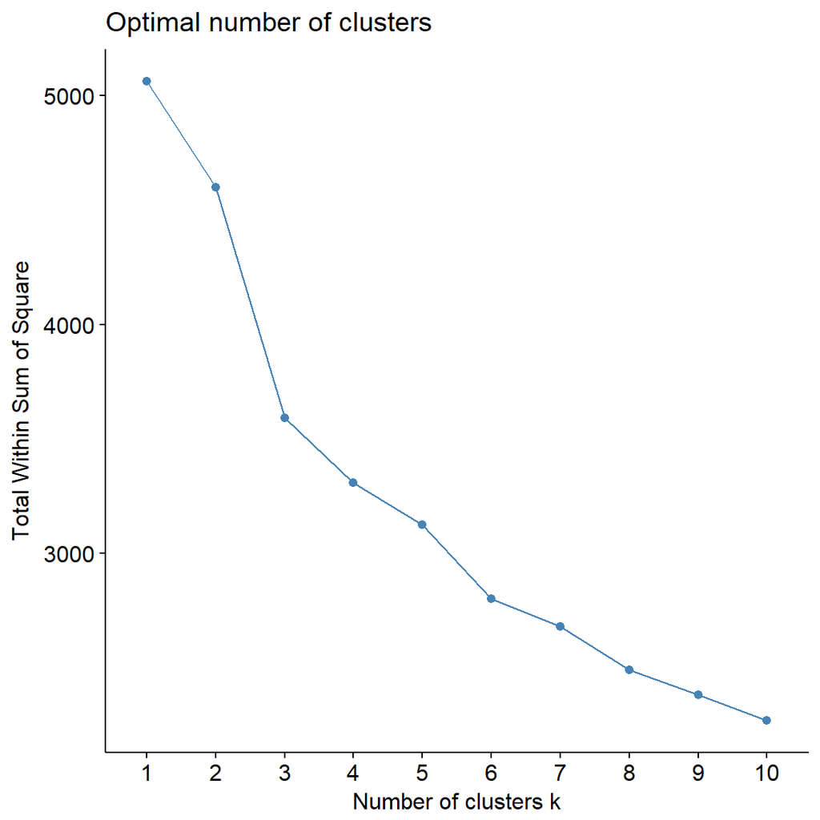

```r
library(NbClust)
#데이터 표준화
ntrain=scale(train[,names(train)!='diabetes'])
ntest=scale(test[,names(test)!="diabetes"])
fviz_nbclust(ntrain, kmeans, method="wss")
```

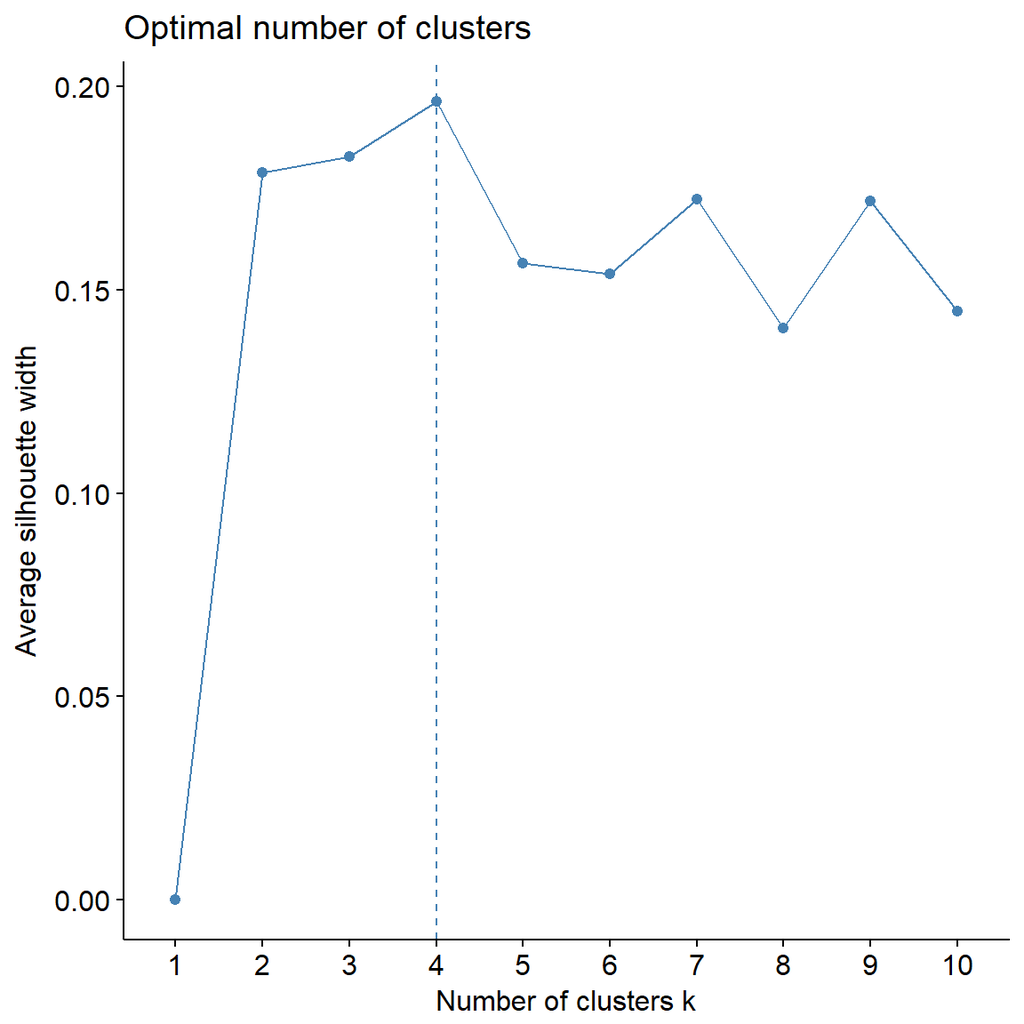

```r
fviz_nbclust(ntrain, kmeans, method="silhouette")
```

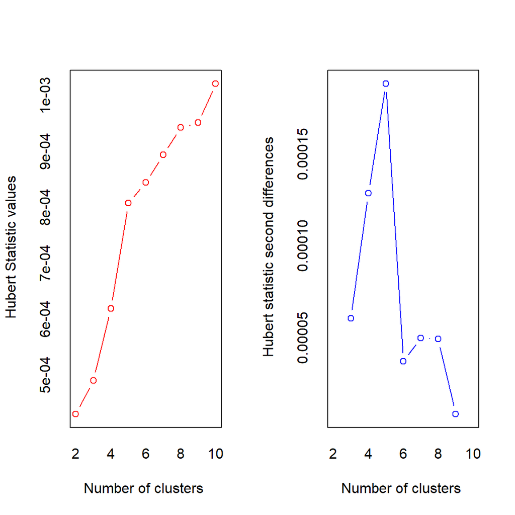

```
## *** : The Hubert index is a graphical method of determining the number of clusters.
##                 In the plot of Hubert index, we seek a significant knee that corresponds to a
##                 significant increase of the value of the measure i.e the significant peak in Hubert
##                 index second differences plot.
##
```

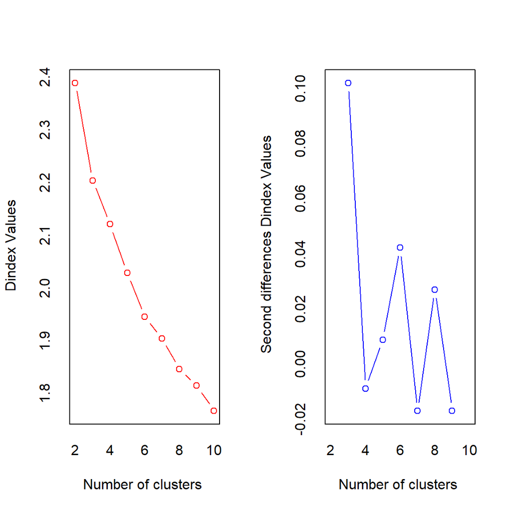

```
## *** : The D index is a graphical method of determining the number of clusters.
##                 In the plot of D index, we seek a significant knee (the significant peak in Dindex
##                 second differences plot) that corresponds to a significant increase of the value of
##                 the measure.
##
## * Among all indices:
## * 4 proposed 2 as the best number of clusters
## * 9 proposed 3 as the best number of clusters
## * 4 proposed 5 as the best number of clusters
## * 2 proposed 7 as the best number of clusters
## * 1 proposed 8 as the best number of clusters
## * 3 proposed 10 as the best number of clusters
##
##                    ***** Conclusion *****
##
## * According to the majority rule, the best number of clusters is  3
##
##
```

```r
nb = NbClust(ntrain, distance = "euclidean", min.nc = 2,           max.nc = 10, method = "kmeans")
```

```
## Among all indices:
## ===================
## * 2 proposed  0 as the best number of clusters
## * 1 proposed  1 as the best number of clusters
## * 4 proposed  2 as the best number of clusters
## * 9 proposed  3 as the best number of clusters
## * 4 proposed  5 as the best number of clusters
## * 2 proposed  7 as the best number of clusters
## * 1 proposed  8 as the best number of clusters
## * 3 proposed  10 as the best number of clusters
##
## Conclusion
## =========================
## * According to the majority rule, the best number of clusters is  3 .
```

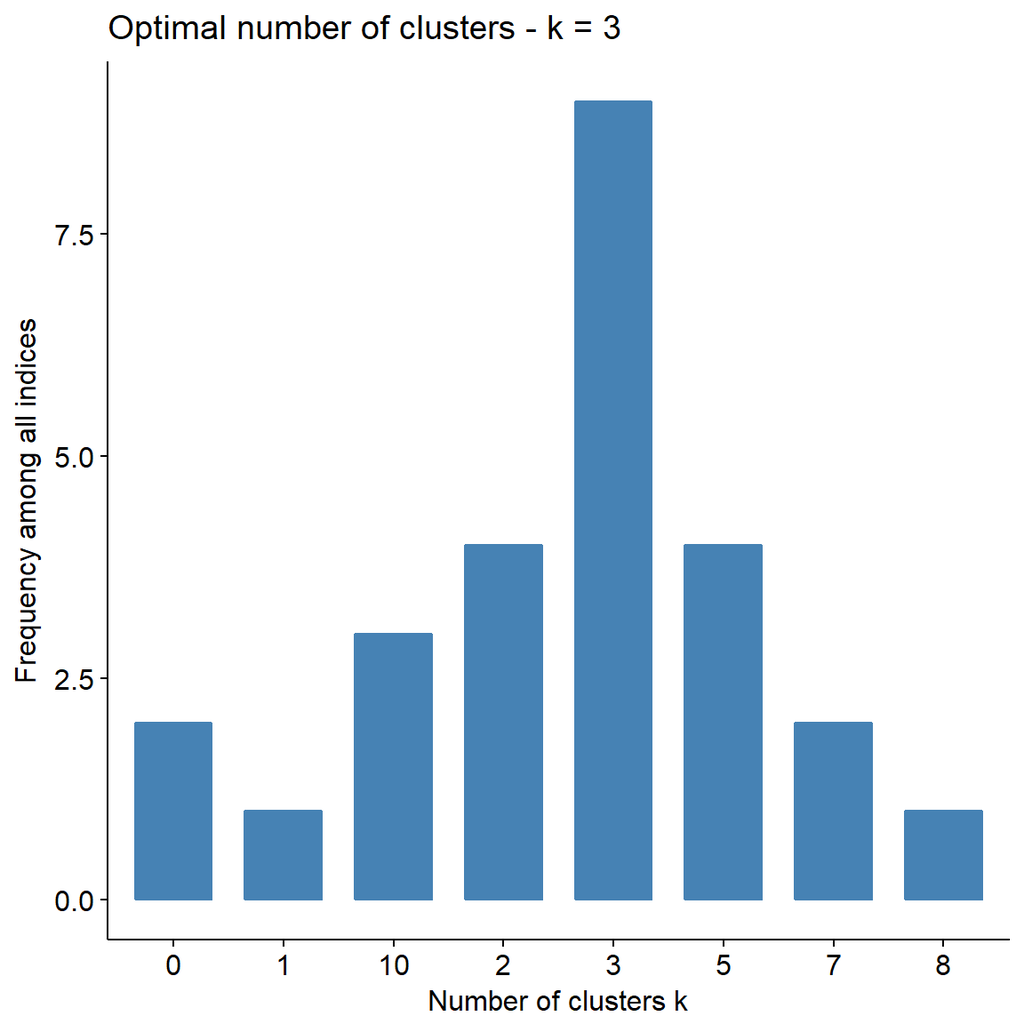

```r
fviz_nbclust(nb)
```

```r
library(fpc)
cboot<-clusterboot(ntrain, clustermethod=kmeansCBI,k=3)
```

[output not shown]

[output cut: 45 more lines]

[output not shown]

```r
cboot$bootmean
```

```
## [1] 0.8866124 0.8363286 0.8758050
```

```r
cboot$bootbrd
```

```
## [1]  3 11  5
```

```r
#군집은 3이 제일 적절한 같으므로 이로 분석

pclusters <- kmeans(ntrain, 3, nstart=100, iter.max=100)
pclusters$centers
```

```
##     pregnant    glucose   pressure    triceps    insulin        mass
## 1 -0.4966425 -0.5608750 -0.4401228 -0.2411577 -0.3244773 -0.41271335
## 2  1.0209515  0.2746805  0.4142889 -0.4894561 -0.4724971  0.01036385
## 3 -0.2541749  0.6321178  0.2880385  0.9076080  1.0264656  0.66581204
##      pedigree         age
## 1 -0.21321393 -0.63021796
## 2 -0.06925845  1.05509633
## 3  0.42205146 -0.07090624
```

```r
head(pclusters$cluster)
```

```
## 1 2 3 4 5 6
## 2 1 2 1 3 1
```

```r
pclusters$size
```

```
## [1] 282 180 172
```

# 8 문제 4

train 데이터를 가지고 logistic 회귀분석을 모델을 만들고, test 데이터로 예측하고, 혼동행렬을 구하고 몇 가지 지표로 평가하시오.

```r
glmodel=glm(diabetes~.,data=train,family = binomial(link = "logit"))
test$pred=predict(glmodel,test,type = "response")

test$level=ifelse(test$pred>=0.5,"pos","neg")
test$level=factor(test$level)
confusionMatrix(test$level,reference=test$diabetes)
```

```
## Confusion Matrix and Statistics
##
##           Reference
## Prediction neg pos
##        neg  79  17
##        pos  14  23
##
##                Accuracy : 0.7669
##                  95% CI : (0.6858, 0.8358)
##     No Information Rate : 0.6992
##     P-Value [Acc > NIR] : 0.05151
##
##                   Kappa : 0.4337
##  Mcnemar's Test P-Value : 0.71944
##
##             Sensitivity : 0.8495
##             Specificity : 0.5750
##          Pos Pred Value : 0.8229
##          Neg Pred Value : 0.6216
##              Prevalence : 0.6992
##          Detection Rate : 0.5940
##    Detection Prevalence : 0.7218
##       Balanced Accuracy : 0.7122
##
##        'Positive' Class : neg
##
```

# 9 문제 5

문제 4에서 ROC 곡선을 그리고 AUC 를 구하시오.

```r
library(ROCR)
```

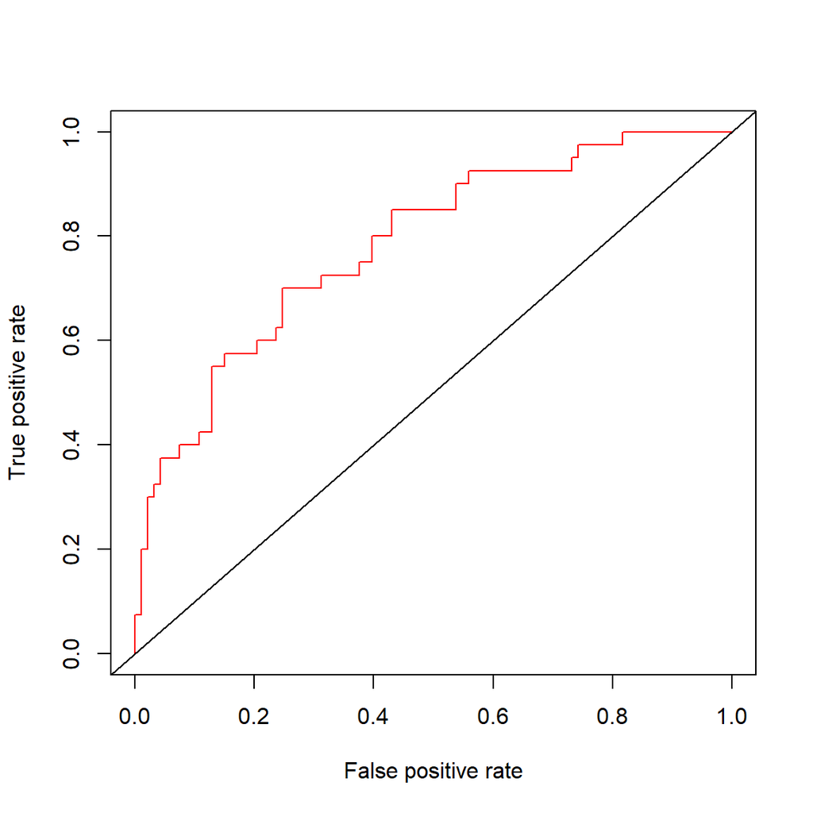

```r
prd1 = prediction(test$pred, test$diabetes)
perf1 = performance(prd1, "tpr", "fpr")
plot(perf1,col="red")
abline(a=0, b=1)
```

```r
performance(prd1, 'auc')@y.values[[1]]
```

```
## [1] 0.7827957
```

# 10 문제 6

다음의 Groceries 자료를 활용하시오.

```r
library(arules)
data(Groceries)
str(Groceries)
```

```
## Formal class 'transactions' [package "arules"] with 3 slots
##   ..@ data       :Formal class 'ngCMatrix' [package "Matrix"] with 5 slots
##   .. .. ..@ i       : int [1:43367] 13 60 69 78 14 29 98 24 15 29 ...
##   .. .. ..@ p       : int [1:9836] 0 4 7 8 12 16 21 22 27 28 ...
##   .. .. ..@ Dim     : int [1:2] 169 9835
##   .. .. ..@ Dimnames:List of 2
##   .. .. .. ..$ : NULL
##   .. .. .. ..$ : NULL
##   .. .. ..@ factors : list()
##   ..@ itemInfo   :'data.frame':  169 obs. of  3 variables:
##   .. ..$ labels: chr [1:169] "frankfurter" "sausage" "liver loaf" "ham" ...
##   .. ..$ level2: Factor w/ 55 levels "baby food","bags",..: 44 44 44 44 44 44 44 42 42 41 ...
##   .. ..$ level1: Factor w/ 10 levels "canned food",..: 6 6 6 6 6 6 6 6 6 6 ...
##   ..@ itemsetInfo:'data.frame':  0 obs. of  0 variables
```

```r
summary(Groceries)
```

```
## transactions as itemMatrix in sparse format with
##  9835 rows (elements/itemsets/transactions) and
##  169 columns (items) and a density of 0.02609146
##
## most frequent items:
##       whole milk other vegetables       rolls/buns             soda
##             2513             1903             1809             1715
##           yogurt          (Other)
##             1372            34055
##
## element (itemset/transaction) length distribution:
## sizes
##    1    2    3    4    5    6    7    8    9   10   11   12   13   14   15
## 2159 1643 1299 1005  855  645  545  438  350  246  182  117   78   77   55
##   16   17   18   19   20   21   22   23   24   26   27   28   29   32
##   46   29   14   14    9   11    4    6    1    1    1    1    3    1
##
##    Min. 1st Qu.  Median    Mean 3rd Qu.    Max.
##   1.000   2.000   3.000   4.409   6.000  32.000
##
## includes extended item information - examples:
##        labels  level2           level1
## 1 frankfurter sausage meat and sausage
## 2     sausage sausage meat and sausage
## 3  liver loaf sausage meat and sausage
```

```r
colnames(Groceries)
```

```
##   [1] "frankfurter"               "sausage"
##   [3] "liver loaf"                "ham"
##   [5] "meat"                      "finished products"
##   [7] "organic sausage"           "chicken"
##   [9] "turkey"                    "pork"
##  [11] "beef"                      "hamburger meat"
##  [13] "fish"                      "citrus fruit"
##  [15] "tropical fruit"            "pip fruit"
##  [17] "grapes"                    "berries"
##  [19] "nuts/prunes"               "root vegetables"
##  [21] "onions"                    "herbs"
##  [23] "other vegetables"          "packaged fruit/vegetables"
##  [25] "whole milk"                "butter"
##  [27] "curd"                      "dessert"
##  [29] "butter milk"               "yogurt"
```

[output cut: 70 more lines]

Groceries 자료를 가지고 연관규칙 분석을 하시오.

```r
itemFrequency(Groceries)
```

```
##               frankfurter                   sausage
##              0.0589730554              0.0939501779
##                liver loaf                       ham
##              0.0050838841              0.0260294865
##                      meat         finished products
##              0.0258261312              0.0065073716
##           organic sausage                   chicken
##              0.0022369090              0.0429079817
##                    turkey                      pork
##              0.0081342145              0.0576512456
##                      beef            hamburger meat
##              0.0524656838              0.0332486019
##                      fish              citrus fruit
##              0.0029486528              0.0827656329
##            tropical fruit                 pip fruit
##              0.1049313676              0.0756481952
##                    grapes                   berries
##              0.0223690900              0.0332486019
##               nuts/prunes           root vegetables
##              0.0033553635              0.1089984748
##                    onions                     herbs
##              0.0310116929              0.0162684291
##          other vegetables packaged fruit/vegetables
##              0.1934926284              0.0130147433
##                whole milk                    butter
##              0.2555160142              0.0554143366
##                      curd                   dessert
##              0.0532791052              0.0371123538
##               butter milk                    yogurt
##              0.0279613625              0.1395017794
##        whipped/sour cream                 beverages
##              0.0716827656              0.0260294865
##                  UHT-milk            condensed milk
##              0.0334519573              0.0102694459
##                     cream               soft cheese
##              0.0013218099              0.0170818505
##             sliced cheese               hard cheese
##              0.0245043213              0.0245043213
##             cream cheese           processed cheese
##              0.0396542959              0.0165734621
```

[output cut: 115 more lines]

```
##              0.0027452974              0.0004067107
##           cling film/bags            kitchen towels
##              0.0113879004              0.0059989832
##    house keeping products                   candles
##              0.0083375699              0.0089476360
##               light bulbs      sound storage medium
##              0.0041687850              0.0001016777
##                newspapers                photo/film
##              0.0798169802              0.0092526690
##                pot plants    flower soil/fertilizer
##              0.0172852059              0.0019318760
##            flower (seeds)             shopping bags
##              0.0103711235              0.0985256736
##                      bags
##              0.0004067107
```

```r
median(itemFrequency(Groceries))
```

```
## [1] 0.0104728
```

```r
mean(itemFrequency(Groceries))
```

```
## [1] 0.02609146
```

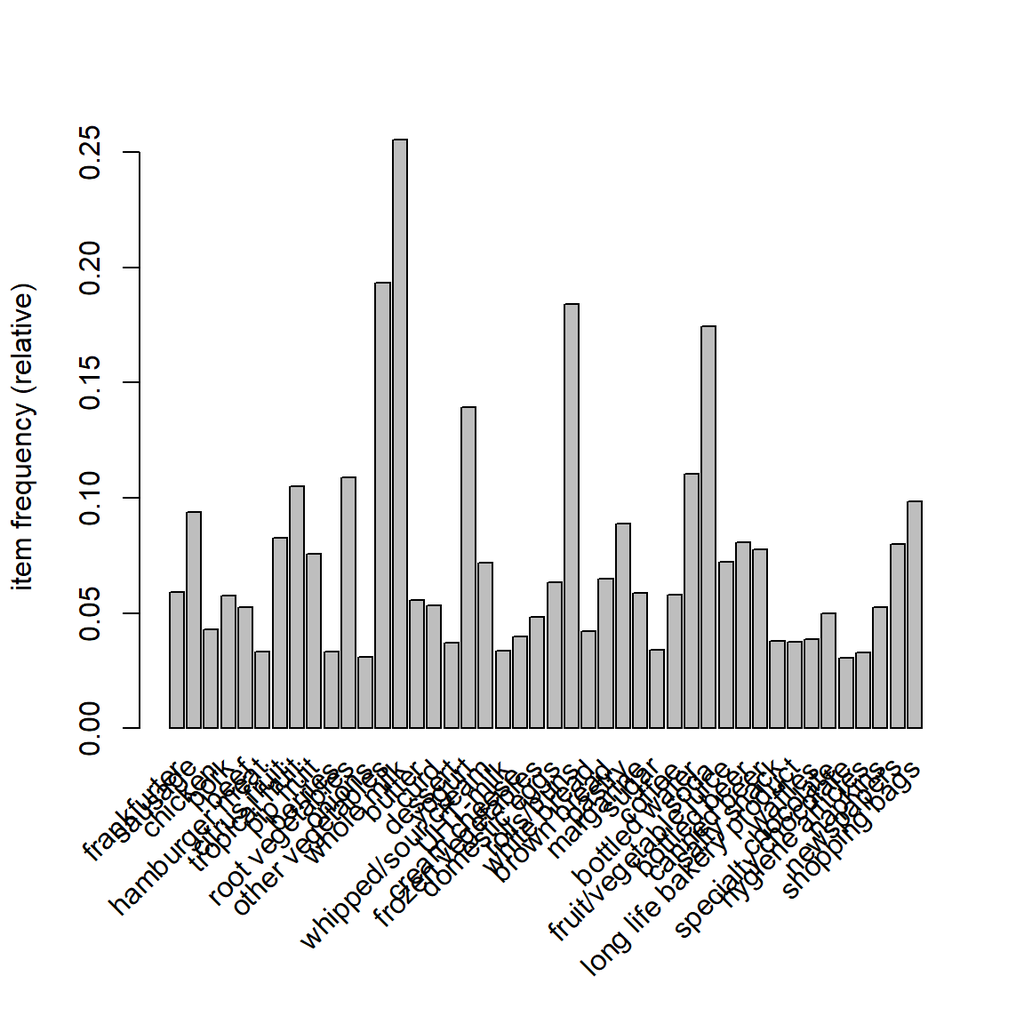

```r
itemFrequencyPlot(Groceries, support= 0.03)
```

```r
#지지도의 평균값인 0.026 보다 큰 0.03 이상인 것들을 분석
myrules=apriori(data=Groceries,parameter = list(support=0.03,confidence = 0.1, minlen =2))
```

```
## Apriori
##
## Parameter specification:
##  confidence minval smax arem  aval originalSupport maxtime support minlen
##         0.1    0.1    1 none FALSE            TRUE       5    0.03      2
##  maxlen target   ext
##      10  rules FALSE
##
## Algorithmic control:
##  filter tree heap memopt load sort verbose
##     0.1 TRUE TRUE  FALSE TRUE    2    TRUE
##
## Absolute minimum support count: 295
##
## set item appearances ...[0 item(s)] done [0.00s].
## set transactions ...[169 item(s), 9835 transaction(s)] done [0.01s].
## sorting and recoding items ... [44 item(s)] done [0.00s].
## creating transaction tree ... done [0.01s].
## checking subsets of size 1 2 3 done [0.00s].
## writing ... [38 rule(s)] done [0.00s].
## creating S4 object  ... done [0.00s].
```

```r
summary(myrules)
```

```
## set of 38 rules
##
## rule length distribution (lhs + rhs):sizes
##  2
## 38
##
##    Min. 1st Qu.  Median    Mean 3rd Qu.    Max.
##       2       2       2       2       2       2
##
## summary of quality measures:
##     support          confidence          lift            count
##  Min.   :0.03010   Min.   :0.1178   Min.   :0.8991   Min.   :296.0
##  1st Qu.:0.03287   1st Qu.:0.1858   1st Qu.:1.2080   1st Qu.:323.2
##  Median :0.03833   Median :0.2271   Median :1.5136   Median :377.0
##  Mean   :0.04129   Mean   :0.2594   Mean   :1.4767   Mean   :406.1
##  3rd Qu.:0.04639   3rd Qu.:0.3380   3rd Qu.:1.7191   3rd Qu.:456.2
##  Max.   :0.07483   Max.   :0.4496   Max.   :2.2466   Max.   :736.0
##
## mining info:
##       data ntransactions support confidence
##  Groceries          9835    0.03        0.1
```

```r
inspect(sort(myrules, by = "lift")[1:5])
```

```
##     lhs                   rhs                support    confidence
## [1] {root vegetables}  => {other vegetables} 0.04738180 0.4347015
## [2] {other vegetables} => {root vegetables}  0.04738180 0.2448765
## [3] {sausage}          => {rolls/buns}       0.03060498 0.3257576
## [4] {rolls/buns}       => {sausage}          0.03060498 0.1663903
## [5] {tropical fruit}   => {other vegetables} 0.03589222 0.3420543
##     lift     count
## [1] 2.246605 466
## [2] 2.246605 466
## [3] 1.771048 301
## [4] 1.771048 301
## [5] 1.767790 353
```

리프트가 충분히 큰 관계는 뿌리채소를 사면 다른 채소를 산다는 것, 다른 채소를 사면 뿌리채소를 산다는 관계가 있다. 다음으로 소세지를 사면 번이나 롤빵을, 그 반대 관계도 성립하고, 열대과일을 사면 다른 채소를 샀다.

# 11 문제 7

인터넷에서 한글 텍스트 파일 하나 다운받아서 워드 클라우드 만드시오.

```r
Sys.setenv(JAVA_HOME="C:/Program Files/Java/jre1.8.0_171")
library(rJava)
library(KoNLP)
library(dplyr)
```

```r
library(wordcloud)
useNIADic()
```

```
## Backup was just finished!
## 983012 words dictionary was built.
```

```r
text<- readLines('C:/Users/Home/Desktop/park.txt')
nouns <- sapply(text, extractNoun, USE.NAMES = F)
nouns = unlist(nouns)
nouns2 <- nouns[nchar(nouns) >= 2]
wordcount = table(nouns2)
wc = sort(wordcount, decreasing = T)
wc
```

```
## nouns2
##     국민   여러분     검찰     수사     책임     마음     국정     인연
##       11        8        6        6        6        5        4        4
##     잘못     가슴     각오     도움     생각     염려     이번   청와대
##        4        3        3        3        3        3        3        3
##     개인     결과     경제     공백     규명 대한민국     동력     마땅
##        2        2        2        2        2        2        2        2
##     만큼     무엇     사실     상황     설명     성장     실망     용서
##        2        2        2        2        2        2        2        2
##     우리     정부     조사     종교     진상     진행     특별     하지
##        2        2        2        2        2        2        2        2
##     협조     가족     각계   걸림돌     검사     경계     경위   경호실
##        2        1        1        1        1        1        1        1
##     계속     공정   공직자     과정     과제     관련     교류     구속
##        1        1        1        1        1        1        1        1
##     구애     구체     국가   국내외     국회   그동안     기능     기업
##        1        1        1        1        1        1        1        1
##     기회 꺼트리지   나머지     내용     노력     누구     담장   대통령
##        1        1        1        1        1        1        1        1
## 대통령의     대표     드립     때문     로운     말씀     머리 명명백백
##        1        1        1        1        1        1        1        1
##     미래     바람     반대     밤잠     범죄     본부     본연     불미
##        1        1        1        1        1        1        1        1
##     불찰     비리   비서실     사건     사들     사람   사람들 사법처리
##        1        1        1        1        1        1        1        1
##     사사     사이     사죄     사태     사회     산적     상응     상처
##        1        1        1        1        1        1        1        1
##     상태     선의     성실     소통     솔직     송구   수사가     수석
##        1        1        1        1        1        1        1        1
##     수용   스스로     시절     신속     심정     안보   안종범     어제
##        1        1        1        1        1        1        1        1
##     엄격     엄정     오늘     왕래     요구 우리나라     위법     유한
##        1        1        1        1        1        1        1        1
##     이러   이야기     이후     인정     일부     임기   자괴감     적극
##        1        1        1        1        1        1        1        1
##     정도     정성 정책조정     존경     죄송     주변     중단     중대
##        1        1        1        1        1        1        1        1
##     지도     지시     직면     진실     진심     참담     철저     체포
##        1        1        1        1        1        1        1        1
##     추궁     추진     토대     통감     특정     필요     하기     행위
##        1        1        1        1        1        1        1        1
##     헌신     현실     현안     현장     혐의     혼란     회복
##        1        1        1        1        1        1        1
```

```r
nouns2 <- gsub(pattern = "드립", replacement ="", nouns2)
nouns2 <- gsub(pattern = "하지", replacement ="", nouns2)
nouns2 <- gsub(pattern = "무엇", replacement ="", nouns2)
nouns2 <- gsub(pattern = "꺼뜨리지", replacement ="", nouns2)
nouns2 <- gsub(pattern = "로운", replacement ="", nouns2)
nouns2 <- gsub(pattern = "때문", replacement ="", nouns2)
nouns2 <- gsub(pattern = "만큼", replacement ="", nouns2)
nouns2 <- gsub(pattern = "사들", replacement ="", nouns2)
nouns2 <- gsub(pattern = "사사", replacement ="", nouns2)
nouns2 <- gsub(pattern = "이러", replacement ="", nouns2)
nouns2 <- gsub(pattern = "자분", replacement ="", nouns2)
nouns2 <- gsub(pattern = "^수사가", replacement ="", nouns2)
nouns2 <- gsub(pattern = "^최순실씨가", replacement ="", nouns2)
nouns2 <- gsub(pattern = "^최순실씨로부터", replacement ="", nouns2)
nouns2 <- gsub(pattern = "^사람들", replacement ="", nouns2)
nouns2 <- gsub(pattern = "^대통령의", replacement ="", nouns2)

nouns2 = nouns2[nchar(nouns2) >= 2]
wordcount = table(nouns2)
names(wc)
```

```
##   [1] "국민"     "여러분"   "검찰"     "수사"     "책임"     "마음"
##   [7] "국정"     "인연"     "잘못"     "가슴"     "각오"     "도움"
##  [13] "생각"     "염려"     "이번"     "청와대"   "개인"     "결과"
##  [19] "경제"     "공백"     "규명"     "대한민국" "동력"     "마땅"
##  [25] "만큼"     "무엇"     "사실"     "상황"     "설명"     "성장"
##  [31] "실망"     "용서"     "우리"     "정부"     "조사"     "종교"
##  [37] "진상"     "진행"     "특별"     "하지"     "협조"     "가족"
##  [43] "각계"     "걸림돌"   "검사"     "경계"     "경위"     "경호실"
##  [49] "계속"     "공정"     "공직자"   "과정"     "과제"     "관련"
##  [55] "교류"     "구속"     "구애"     "구체"     "국가"     "국내외"
##  [61] "국회"     "그동안"   "기능"     "기업"     "기회"     "꺼트리지"
##  [67] "나머지"   "내용"     "노력"     "누구"     "담장"     "대통령"
##  [73] "대통령의" "대표"     "드립"     "때문"     "로운"     "말씀"
##  [79] "머리"     "명명백백" "미래"     "바람"     "반대"     "밤잠"
##  [85] "범죄"     "본부"     "본연"     "불미"     "불찰"     "비리"
##  [91] "비서실"   "사건"     "사들"     "사람"     "사람들"   "사법처리"
##  [97] "사사"     "사이"     "사죄"     "사태"     "사회"     "산적"
## [103] "상응"     "상처"     "상태"     "선의"     "성실"     "소통"
## [109] "솔직"     "송구"     "수사가"   "수석"     "수용"     "스스로"
## [115] "시절"     "신속"     "심정"     "안보"     "안종범"   "어제"
## [121] "엄격"     "엄정"     "오늘"     "왕래"     "요구"     "우리나라"
## [127] "위법"     "유한"     "이러"     "이야기"   "이후"     "인정"
## [133] "일부"     "임기"     "자괴감"   "적극"     "정도"     "정성"
## [139] "정책조정" "존경"     "죄송"     "주변"     "중단"     "중대"
## [145] "지도"     "지시"     "직면"     "진실"     "진심"     "참담"
## [151] "철저"     "체포"     "추궁"     "추진"     "토대"     "통감"
## [157] "특정"     "필요"     "하기"     "행위"     "헌신"     "현실"
## [163] "현안"     "현장"     "혐의"     "혼란"     "회복"
```

```r
wc = sort(wordcount, decreasing = T)
wc
```

```
## nouns2
##     국민   여러분     검찰     수사     책임     마음     국정     인연
##       11        8        6        6        6        5        4        4
##     잘못     가슴     각오     도움     생각     염려     이번   청와대
##        4        3        3        3        3        3        3        3
##     개인     결과     경제     공백     규명 대한민국     동력     마땅
##        2        2        2        2        2        2        2        2
##     사실     상황     설명     성장     실망     용서     우리     정부
##        2        2        2        2        2        2        2        2
##     조사     종교     진상     진행     특별     협조     가족     각계
##        2        2        2        2        2        2        1        1
##   걸림돌     검사     경계     경위   경호실     계속     공정   공직자
##        1        1        1        1        1        1        1        1
##     과정     과제     관련     교류     구속     구애     구체     국가
##        1        1        1        1        1        1        1        1
##   국내외     국회   그동안     기능     기업     기회 꺼트리지   나머지
##        1        1        1        1        1        1        1        1
##     내용     노력     누구     담장   대통령     대표     말씀     머리
##        1        1        1        1        1        1        1        1
## 명명백백     미래     바람     반대     밤잠     범죄     본부     본연
##        1        1        1        1        1        1        1        1
##     불미     불찰     비리   비서실     사건     사람 사법처리     사이
##        1        1        1        1        1        1        1        1
##     사죄     사태     사회     산적     상응     상처     상태     선의
##        1        1        1        1        1        1        1        1
##     성실     소통     솔직     송구     수석     수용   스스로     시절
##        1        1        1        1        1        1        1        1
##     신속     심정     안보   안종범     어제     엄격     엄정     오늘
##        1        1        1        1        1        1        1        1
##     왕래     요구 우리나라     위법     유한   이야기     이후     인정
##        1        1        1        1        1        1        1        1
##     일부     임기   자괴감     적극     정도     정성 정책조정     존경
##        1        1        1        1        1        1        1        1
##     죄송     주변     중단     중대     지도     지시     직면     진실
##        1        1        1        1        1        1        1        1
##     진심     참담     철저     체포     추궁     추진     토대     통감
##        1        1        1        1        1        1        1        1
##     특정     필요     하기     행위     헌신     현실     현안     현장
##        1        1        1        1        1        1        1        1
##     혐의     혼란     회복
##        1        1        1
```

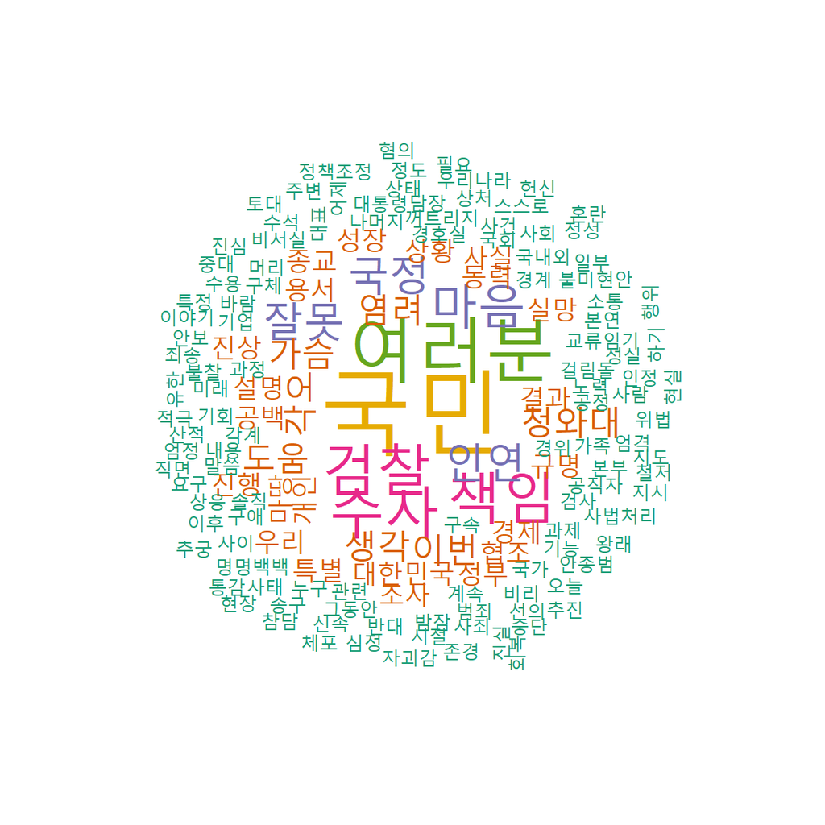

```r
pal <- brewer.pal(6, "Dark2")
windowsFonts(malgun=windowsFont("맑은 고딕"))
wordcloud(words=names(wc), freq=wc, colors=pal, min.freq=1, scale = c(4, 0.5),
          random.order=F, family="malgun")
```